# Election Project

Shanaaz Deo, Derrick Lin, Kimberly Mahoney, Vinitra Swamy, Allen Wang

## Step 0, Required settings, libraries, and quick load

Run this command before proceeding and install all packages below. This formats data frame, loads state names, and loads libraries. Read comments below to load data frame.

```r
# Global settings
options(stringsAsFactors = FALSE)
states <- read.table("http://www.stat.berkeley.edu/users/nolan/data/voteProject/countyVotes2012/stateNames.txt",
                    header = TRUE)
states <- states$states[-2] # Alaska is not present in all data, so we ignore it.

# Data wrangling
require(XML)
require(googlesheets)

# Formatting and plotting
require(reshape2)
require(plyr)
require(ggplot2)

# Map
require("choroplethr")
require("choroplethrMaps")
require("scales")

# Classifier
require(rpart)
library(rpart.plot)

# Boolean to tag which code chunks to run. Switch to true if you make any changes to the data frames.
createMasterFrame = TRUE
```

# Introduction

On November 8th, the presidential election was coming to a close. While some students at UC Berkeley were eagerly encouraging their fellow students to vote for Hillary Clinton, other students did not feel the need to; how in the world could Trump be elected, they thought? Unfortunately, the student population of UC Berkeley was proven wrong, and presidential elect Trump beat out Clinton in what has turned out to be one of the most controversial presidential races in history.

Polls were made, and predictions were formed off of the culminated data. Hillary Clinton had a supposed 71.4% chance of winning. How could Data Science have let us down in this crucial time? Fortunately, the analytical journey doesn’t end here; by doing an analysis on the election data from the years 2004, 2008, 2010, 2012, and the current year (2016), we can see how the voters’ opinions have swayed throughout the years, and how the dynamically shifting atmosphere of the world has impacted the voters’ decisions.

In this project, we were able to use the various skills learned in this class to perform data scraping and visual analysis. By using a combination of ggplot, map creation, and supervised learning techniques, we were able to model our results, create predictors, and compare our predictions to the correct data sets.

## Step 1 - Data Cleaning

### 1.1 - Extracting 2016 Election Data

Reads and parses the CSV for the 2016 election results. Only extracts the columns for votes per candidate, state name, county,and county id. Differences, and total votes are ignored as other data sets do not store these. State names and county names are included despite county id being unique because it’s possible some counties were only recoreded in the 2016 data. Stored it in df2016. *Done by Derrick and Shanaaz*

```r
data2016 <- read.csv("https://raw.githubusercontent.com/tonmcg/County_Level_Election_Results_12-16/master/2016_US_County_Level_Presidential_Results.csv")
demVoteCount2016 <- data2016$votes_dem
repVoteCount2016 <- data2016$votes_gop
perDemVotes2016 <- data2016$per_dem
perRepVotes2016 <- data2016$per_gop
geoIDs2016 <- data2016$combined_fips
stateAbbr2016 <- tolower(data2016$state_abbr)
countyNames2016 <- tolower(sub("( Parish)|( County)", "", data2016$county_name))
countyNames2016 <- sub("\\.", "", countyNames2016)


citiesToRemove <- c("alexandria city", "bristol city", "buena vista city", "charlottesville city", "chesapeake city", "colonial heights city", "covington city", "danville city", "emporia city", "falls church city", "fredericksburg city", "galax city", "hampton city", "harrisonburg city", "hopewell city", "lexington city", "lynchburg city", "manassas city", "manassas park city", "martinsville city", "newport news city", "norfolk city", "norton city", "petersburg city", "poquoson city", "portsmouth city", "radford city", "salem city", "staunton city", "suffolk city", "virginia beach city", "waynesboro city", "williamsburg city", "winchester city","jefferson davis", "le flore", "de soto")

replaceWith <- c(sub(" city", "", citiesToRemove), "jeff davis", "leflore","desoto")

for (i in 1:length(citiesToRemove)){
  countyNames2016[grep(citiesToRemove[i], countyNames2016)] = replaceWith[i]
}

df2016 <- data.frame(countyNames2016, stateAbbr2016, demVoteCount2016, perDemVotes2016, repVoteCount2016, perRepVotes2016, geoIDs2016)
```

### 1.2 - Extracting 2012 Election Data

Extracts the xml files for each state. We ignore Alaska as it doesn’t have an entry for it. We then use a series of XPATHs to extract data for each state. *Done by Derrick, Vinitra, and Shanaaz*

```r
generateStateURL <- function (state) {
  return(paste("http://www.stat.berkeley.edu/users/nolan/data/voteProject/countyVotes2012/", state,".xml", sep = ""))
}
generateURLs2012 <- sapply(states, generateStateURL)
stateData2012 <- sapply(generateURLs2012, function(l) xmlParse(l))
stateRoots2012 <- sapply(stateData2012, function(state) xmlRoot(state))

# The county ids for 2012
countyNodeSet2012 <- sapply(stateRoots2012, function(root)getNodeSet(root, "//tbody[@id]"))

# get geogID
geoIDs2012 <- sapply(countyNodeSet2012, function(node) xmlSApply(node, xmlGetAttr, "id"))
stateNames2012 <- unlist(sapply(seq(length(states)), function(i) rep(states[[i]], length(geoIDs2012[[i]]))))
stateNames2012 <- sub("-", " ", stateNames2012)
geoIDs2012 <- sub("county", "", unlist(unname(geoIDs2012)))

# get county names
countyNames2012 <- sapply(stateRoots2012, function(root) xpathSApply(root, '//th[@class="results-county"]', xmlValue))
countyNames2012 <- unlist(unname(countyNames2012))
countyNames2012 <- tolower(sub(" 100.0% Reporting", "", countyNames2012))
countyNames2012 <- countyNames2012[!(countyNames2012 == "county")]

geoIDs2012 <- unlist(unname(geoIDs2012))

# The number of republican votes for 2012
repVoteCount2012 <- unlist(unname(sapply(stateRoots2012, function(root) xpathSApply(root, '//tr[@class="party-republican race-winner"]/td[@class="results-popular"] | //tr[@class="party-republican"]/td[@class="results-popular"]', xmlValue))))
repVoteCount2012 <- sub("^\\s+", "", repVoteCount2012)
repVoteCount2012 <- sub(",", "", repVoteCount2012)

# The number of democrat votes for 2012
demVoteCount2012 <- unlist(unname(sapply(stateRoots2012, function(root) xpathSApply(root, '//tr[@class="party-democrat race-winner"]/td[@class="results-popular"] | //tr[@class="party-democrat"]/td[@class="results-popular"]', xmlValue))))
demVoteCount2012 <- sub("^\\s+", "", demVoteCount2012)
demVoteCount2012 <- sub(",", "", demVoteCount2012)

#The percentage of rep votes for 2012
perRepVotes2012 <- unlist(unname(sapply(stateRoots2012, function(root) xpathSApply(root, '//tr[@class="party-republican race-winner"]/td[@class="results-percentage"] | //tr[@class="party-republican"]/td[@class="results-percentage"]', xmlValue))))

#The percentage of dem votes for 2012
perDemVotes2012 <- unlist(unname(sapply(stateRoots2012, function(root) xpathSApply(root, '//tr[@class="party-democrat race-winner"]/td[@class="results-percentage"] | //tr[@class="party-democrat"]/td[@class="results-percentage"]', xmlValue))))

df2012 <- data.frame(geoIDs2012, stateNames2012, repVoteCount2012, perRepVotes2012, demVoteCount2012, perDemVotes2012, countyNames2012)
```

### Step 1.3 - Extracting 2008 Election Data

Extract sheets one by one from an online google sheet. Formats state names. Has a special condition for California and Maine since they are misformatted. **Warning: this will take a while to run.** *Done by Allen.*

```r
stateNames <- "http://www.stat.berkeley.edu/users/nolan/data/voteProject/countyVotes2012/stateNames.txt"
capitalize <- function(state) {
  words <- strsplit(state, " ")[[1]]
  paste(toupper(substring(words, 1,1)), substring(words, 2), sep="", collapse=" ")
}
states <- read.table(stateNames, header = TRUE)[[1]]
states <- states[states != "district-of-columbia"] # There is no entry for D.C.
states <- gsub("-", " ", states) # Must format to sheet names

sourceURL2008 <- "https://docs.google.com/spreadsheets/d/1gLzjUFBk9gtAPfZ-bNZVfFC1zNhGkY_WI_VD_OXHUYI/edit#gid=0"
demVoteCount2008 <- c()
repVoteCount2008 <- c()
otherCount2008 <- c()
countyNames2008 <- c()
stateNames2008 <- c() # Used to easily align states with counties and votes for the data frame

sapply(states, function(state) {
  if (state == "california" | state == "maine") {
    stateDF <- gs_read(gs_url(sourceURL2008), ws = capitalize(state),
                      col_names = c("County", "Total Precincts", "Precincts Reporting", "Obama", "McCain", "Other"))
  } else {
    stateDF <- gs_read(gs_url(sourceURL2008), ws = capitalize(state))
  }
  countyNames2008 <<- tolower(c(countyNames2008, stateDF$County))
  demVoteCount2008 <<- c(demVoteCount2008, stateDF$Obama)
  repVoteCount2008 <<- c(repVoteCount2008, stateDF$McCain)
  otherCount2008 <<- c(otherCount2008, stateDF$Other)
  stateNames2008 <<- c(stateNames2008, rep(state, length(stateDF$County)))
})


perDemVotes2008 <- demVoteCount2008 / (demVoteCount2008 + otherCount2008 + repVoteCount2008)
perRepVotes2008 <- repVoteCount2008 / (demVoteCount2008 + otherCount2008 + repVoteCount2008)


countyNames2008 <- sub("( county)", "", countyNames2008)
countyNames2008 <- sub("(\\.)", "", countyNames2008)

countyNames2008 <- sub("&", "and", countyNames2008)
countyNames2008 <- sub("saint", "st", countyNames2008)

citiesToReplace2008 <- c("jodaviess", "debaca", "la vaca")

replaceWith2008 <- c("jo daviess", "de baca", "lavaca")

for (i in 1:length(citiesToReplace2008)){
  countyNames2008[grep(citiesToReplace2008[i], countyNames2008)] = replaceWith2008[i]
}


df2008 <- data.frame(countyNames2008, stateNames2008, demVoteCount2008, perDemVotes2008, repVoteCount2008, perRepVotes2008)
```

### Step 1.4 - Extracting 2004 Election Data

Parses text using comma as a deliminator. *Done by Vinitra, Derrick.*

```r
# get dataset
data2004 <- read.table("http://www.stat.berkeley.edu/users/nolan/data/voteProject/countyVotes2004.txt", header = TRUE)

# state and county vectors for 2004
stateCountyList2004 <- as.character(data2004$countyName)
stateNames2004 <- unname(sapply(stateCountyList2004, function(stateCounty)strsplit(stateCounty,",")[[1]][[1]]))
countyNames2004 <- unname(sapply(stateCountyList2004, function(stateCounty)strsplit(stateCounty,",")[[1]][[2]]))

# bush and kerry totals for 2004
repVoteCount2004 <- data2004[[2]]
demVoteCount2004 <- data2004[[3]]

# discovering Virginia
library(rvest)
url <- "https://en.wikipedia.org/wiki/United_States_presidential_election_in_Virginia,_2004"
Virginia2004 <- url %>%
  html() %>%
  html_nodes(xpath='//*[@id="mw-content-text"]/table[4]') %>%
  html_table()
Virginia2004 <- Virginia2004[[1]][1:95, ]

Virginia2004$stateNames2004 = rep("virginia",nrow(Virginia2004))

keeps <- c("County or City", "Kerry #", "Bush #", "stateNames2004")

Virginia2004 = Virginia2004[keeps]

library("plyr")

Virginia2004 = plyr::rename(Virginia2004, c("Kerry #"="demVoteCount2004", "Bush #" = "repVoteCount2004", "County or City" = "countyNames2004"))

Virginia2004 = data.frame(lapply(Virginia2004, function(v) {
  if (is.character(v)) return(tolower(v))
  else return(v)
}))

# create the data frame
df2004 <- data.frame(countyNames2004, stateNames2004, repVoteCount2004, demVoteCount2004)

# put Virginia into the data frame
df2004 = rbind(df2004, Virginia2004)
```

### Step 1.5 - Census Data

Extracts variables from the census data to be processed. We had to clean the county data to be remove the word “county”. *By Kim and Derrick.*

```r
dp03data <- read.csv("http://www.stat.berkeley.edu/users/nolan/data/voteProject/census2010/DP03.csv", header = TRUE)
dp02data <- read.csv("http://www.stat.berkeley.edu/users/nolan/data/voteProject/census2010/DP02.csv")
b01data <- read.csv("http://www.stat.berkeley.edu/users/nolan/data/voteProject/census2010/B01003.csv", header = TRUE)

#3217 rows
cleanCounties <- function(x){
  toReturn <- sapply(strsplit(as.character(x$GEO.display.label), ","), function(x) x[[1]])
  toReturn <- tolower(sub(" County", "", toReturn))

}

dp03data <- read.csv("http://www.stat.berkeley.edu/users/nolan/data/voteProject/census2010/DP03.csv", header = TRUE)

dp03DataSubset <- dp03data[,c("GEO.id2", "HC03_VC04", "HC03_VC13", "HC03_VC49", "HC03_VC50", "HC03_VC51", "HC03_VC52", "HC03_VC56", "HC03_VC58", "HC03_VC166", "HC01_VC123", "HC01_VC122", "HC01_VC112", "HC03_VC97", "HC03_VC90")]

colnames(dp03DataSubset) <- paste("dp03", colnames(dp03DataSubset), sep = "_")

dp03DataSubset$counties <- cleanCounties(dp03data)

#3139 rows
dp02data <- read.csv("http://www.stat.berkeley.edu/users/nolan/data/voteProject/census2010/DP02.csv")

dp02DataSubset <- dp02data[,c("GEO.id2","HC03_VC04", "HC01_VC20", "HC01_VC21", "HC03_VC08","HC03_VC12", "HC03_VC35", "HC03_VC18", "HC03_VC80", "HC03_VC85", "HC03_VC86", "HC03_VC90", "HC03_VC91", "HC03_VC168", "HC03_VC171", "HC01_VC51", "HC03_VC140", "HC03_VC12")]
dp02DataSubset$counties <-  cleanCounties(dp02data)
colnames(dp02DataSubset) <- paste("dp02", colnames(dp02DataSubset), sep = "_")

# 3 factors, 8070 rows .. 2690 counties?
b01data <- read.csv("http://www.stat.berkeley.edu/users/nolan/data/voteProject/census2010/B01003.csv", header = TRUE)

b01Subset <- b01data[, c("POPGROUP.display.label", "HD01_VD01","GEO.id2")]
b01Subset$counties <- cleanCounties(b01data)
```

### Step 1.6 - GML Extraction

Creates the vectors gmlStates, gmlCounties, gmlX, and gmlY to store geographic data of the counties. Extracts the state names in sequence and finds the size of each child. Formats gmlX and gmlY to become coordinates for latitude and longitude. Done by Allen

```r
sourceURLgml <- "http://www.stat.berkeley.edu/~nolan/data/voteProject/counties.gml"
xmlValueTrim <- function(x) xmlValue(x, trim = TRUE)
gmlRoot <- xmlRoot(xmlParse(sourceURLgml))
gmlOrderedStates <- tolower(xpathSApply(gmlRoot, '//doc//state//gml:name[@abbreviation]', fun = xmlValueTrim))
numberTimeStateRepeated <- sapply(xmlChildren(gmlRoot), function(state) xmlSize(state) - 1) #First child is name, not county. Subtract one to account for first child)

gmlStates <- rep(gmlOrderedStates, numberTimeStateRepeated)
gmlCounties <- xpathSApply(gmlRoot, '//doc//state//gml:name[not(@abbreviation)]', fun = xmlValueTrim)
gmlX <- as.numeric(xpathSApply(gmlRoot, '//doc//state//gml:X', fun = xmlValueTrim))
gmlY <- as.numeric(xpathSApply(gmlRoot, '//doc//state//gml:Y', fun = xmlValueTrim))

gmlCounties <- tolower(gmlCounties) # Format county names
gmlCounties <- sub("( parish)|( county)", "", gmlCounties)
gmlCounties <- sub("(\\.)", "", gmlCounties)

for (i in 1:length(citiesToRemove)){
  gmlCounties[grep(citiesToRemove[i], gmlCounties)] = replaceWith[i]
}

latitude <- gmlY / 1000000
longitude <- gmlX / 1000000

gmlDF <- data.frame(gmlStates, gmlCounties ,latitude, longitude)

countyNames2016 <- tolower(sub("( Parish)|( County)", "", data2016$county_name))
```

### Step 1.7 - Data Frame Merge

Merges by geo ids of all frames from steps 1 to 5. Starts by merging dp02 and dp03 to get geoIDS. Then we merge 2016 and 2012 on geoID. We merged the resulting data frame with 2008. We then merged that data frame with 2004. Finally, we merged the GML and census data.

*Done by: everyone*

```r
dp03dp02 <- merge(dp02DataSubset, dp03DataSubset, by.x = c("dp02_GEO.id2"), by.y = c("dp03_GEO.id2"))
colnames(dp03dp02)[colnames(dp03dp02)=="dp02_GEO.id2"] <- "geoIDs"

df16_12 <- merge(x = df2016, y = df2012, by.x = "geoIDs2016", by.y = "geoIDs2012")
colnames(df16_12)[colnames(df16_12)=="geoIDs2016"] <- "geoIDs"
colnames(df16_12)[colnames(df16_12)=="stateAbbr2016"] <- "stateAbbr"
colnames(df16_12)[colnames(df16_12)=="countyNames2016"] <- "countyNames"
colnames(df16_12)[colnames(df16_12)=="stateNames2012"] <- "stateNames"

colnames(df2008)[colnames(df2008)=="countyNames2008"] <- "countyNames"
colnames(df2008)[colnames(df2008)=="stateNames2008"] <- "stateNames"

colnames(df2004)[colnames(df2004)=="countyNames2004"] <- "countyNames"
colnames(df2004)[colnames(df2004)=="stateNames2004"] <- "stateNames"

df16_12_08 <- merge(df16_12, df2008, by=c("countyNames", "stateNames"))

df16_12_08_04 <- merge(df16_12_08, df2004, by=c("countyNames", "stateNames"), all.x = TRUE)

df16_12_08_04_dp0302 <- merge(df16_12_08_04, dp03dp02, by="geoIDs")

df16_12_08_04_dp0302_b01 <- merge(df16_12_08_04_dp0302, b01Subset, by.x = "geoIDs", by.y = "GEO.id2")

# Joining on b01
b01Subset <- b01data[b01data$POPGROUP.id==1,c("GEO.id2", "HD01_VD01")]
colnames(b01Subset)[2] <- "totalPopulation"

df16_12_08_04_dp0302_b01 <- merge(df16_12_08_04_dp0302, b01Subset, by.x = "geoIDs", by.y = "GEO.id2")

# Joining on GML data.
masterFrame <- merge(df16_12_08_04_dp0302_b01, gmlDF, by.x = c("stateNames","countyNames"), by.y = c("gmlStates","gmlCounties"), all.x = TRUE)

# Dropping uneeded columns from merging
drops <- c("counties.y","counties.y", "dp02_counties", "counties", "countyNames2012")
masterFrame <- masterFrame[ , !(names(masterFrame) %in% drops)]

# Writing for easier parsing. Search in home directory, R defaults CWD to that.
save(masterFrame, file = "ElectionsDataFrame.rda")

# Also write as CSV for easy debugging.
write.csv(masterFrame, file = "ElectionsDataFrame.csv")
```

#### **Load in the master frame from your directory, switch location accordingly**

```r
#masterFrame = load("ElectionsDataFrame.rda")
```

## Data Description

The data used in this project is from the 2004, 2008, 2012, and 2016 election. We also integrated demographic data from the 2010 census. For example, we have the percent of families living in poverty, the average household income, and educational attainment for each county. We were supplied this data in the form of text files, google forms, and csv files. In order to combine this data into a single data frame, the files had to be individually uploaded into the .rmd file, cleaned, and given columns to join on. After doing an initial cleaning for the four years of election data we calculated the winning party in each county - Republican, Democrat, or Other. In order to keep our data standardized, we removed the votes for “Other”, and only did an analysis of Republican vs. Democratic in our plots. In addition, the information for certain states/counties was excluded from specific data sets, so we ended up removing the information of those states/counties from all of the data sets (for the merge). For example, we do not include Alaska in our master data frame.

```r
#Part 2- GGPlot

repVotes <- masterFrame$repVoteCount2012
demVotes <- masterFrame$demVoteCount2012

cond <- as.integer(repVotes < demVotes) + 1
```

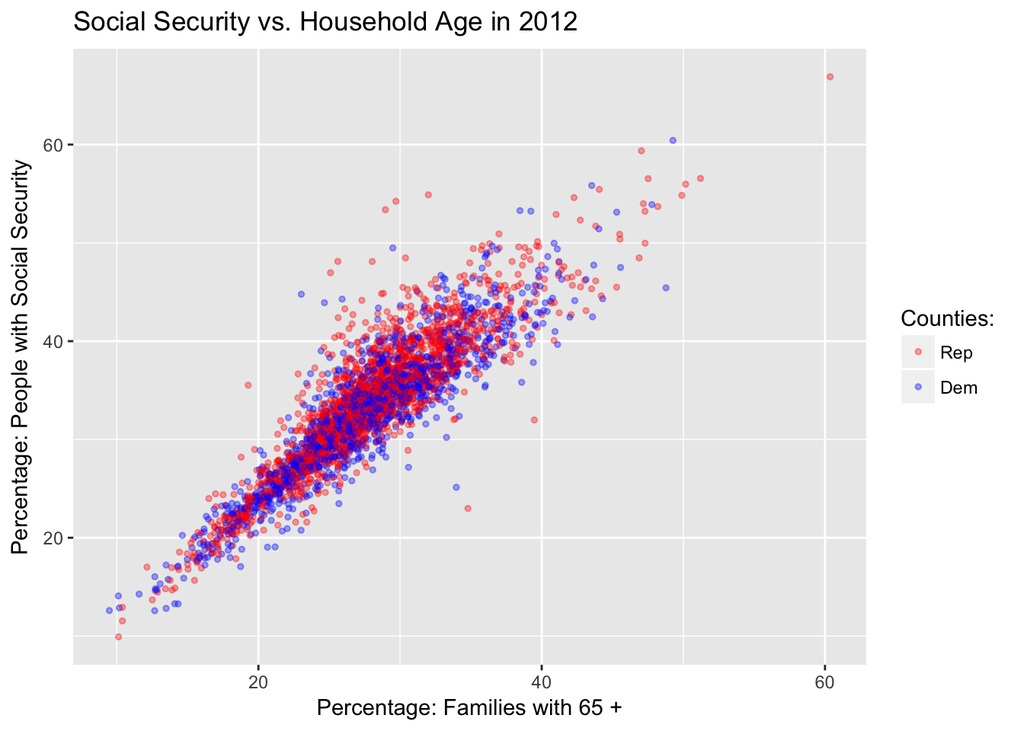

```r
#Scatter Plot 1

ssHouseholdAgeDF <- masterFrame[, c('dp02_HC03_VC18', 'dp03_HC03_VC90')]
ssHouseholdAgeDF['cond'] <- cond
ggplot(data = ssHouseholdAgeDF) +
      geom_point(mapping = aes(x = dp02_HC03_VC18, y = dp03_HC03_VC90, color = factor(cond)), size = 1, position = "jitter", alpha = 0.35) +
      labs(title="Social Security vs. Household Age in 2012") +

      scale_x_continuous("Percentage: Families with 65 +") +
      scale_y_continuous("Percentage: People with Social Security") +
      scale_color_manual(name = "Counties: ", values = c("red", "blue"), labels = c("Rep", "Dem"))
```

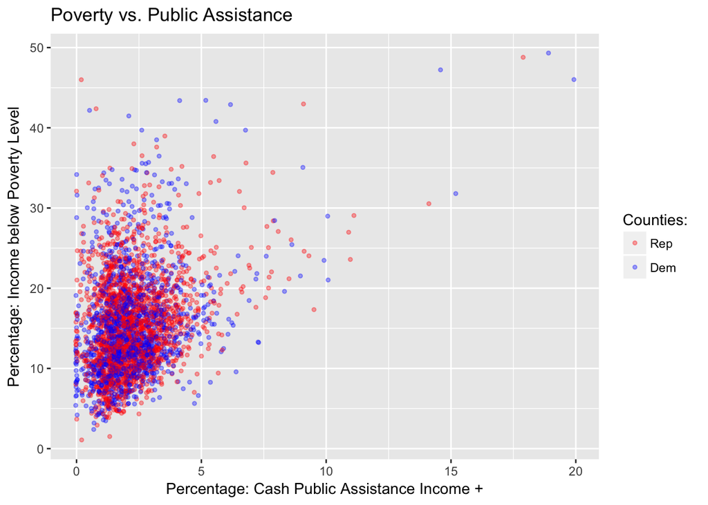

```r
povertyPublicAssistanceDF <- masterFrame[, c('dp03_HC03_VC97', 'dp03_HC03_VC166')]
povertyPublicAssistanceDF['cond'] <- cond
ggplot(data = povertyPublicAssistanceDF) +
      geom_point(mapping = aes(x = dp03_HC03_VC97, y = dp03_HC03_VC166, color = factor(cond)), size = 1, position = "jitter", alpha = 0.35) +
      labs(title = "Poverty vs. Public Assistance") +
      scale_x_continuous("Percentage: Cash Public Assistance Income +") +
      scale_y_continuous("Percentage: Income below Poverty Level") +
      scale_color_manual(name = "Counties: ", values = c("red", "blue"), labels = c("Rep", "Dem"))
```

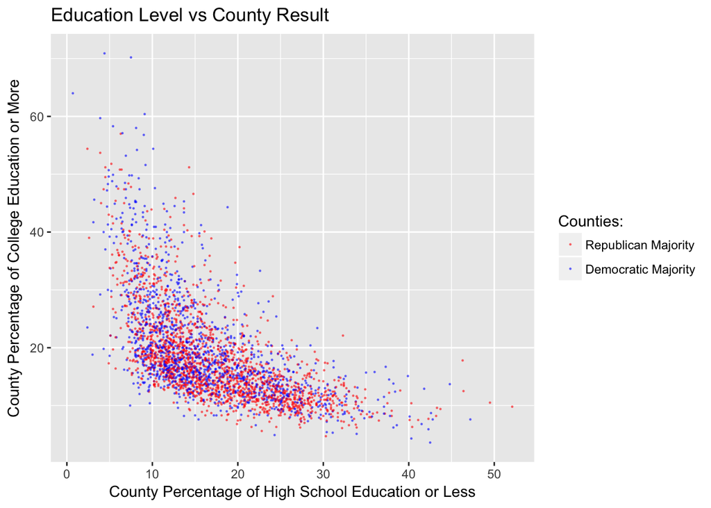

```r
# Scatter Plot of Total Education in America
# - HC03_VC85,Percent; EDUCATIONAL ATTAINMENT - Less than 9th grade
# - HC03_VC86,Percent; EDUCATIONAL ATTAINMENT - 9th to 12th grade, no diploma
# - HC03_VC90,Percent; EDUCATIONAL ATTAINMENT - Bachelor's degree
# - HC03_VC91,Percent; EDUCATIONAL ATTAINMENT - Graduate or professional degree
highSchoolEducationOrLess <- masterFrame$'dp02_HC03_VC85' +  masterFrame$'dp02_HC03_VC86'
collegeOrMore <- masterFrame$'dp02_HC03_VC90' +  masterFrame$'dp02_HC03_VC91'
educationDF <- data.frame(highSchoolEducationOrLess, collegeOrMore)
educationDF['cond'] <- cond
ggplot(data = educationDF) +
      geom_point(mapping = aes(x = highSchoolEducationOrLess, y = collegeOrMore, color = factor(cond)),
                 size = 0.2,
                 position = "jitter",
                 alpha = 0.45) +
      labs(title = "Education Level vs County Result") +
      scale_x_continuous("County Percentage of High School Education or Less") +
      scale_y_continuous("County Percentage of College Education or More") +
      scale_color_manual(name = "Counties: ", values = c("red", "blue"), labels = c("Republican Majority", "Democratic Majority"))
```

*Description* - This graph shows that there is a strong, non-linear negative correlation between High School Education and Less and College Education and More. This is because the subjects in the census only checked one of the boxes. For example, if a person in the census went to college, they would only check the box for College Education and More. It is interesting to note that it is extremely rare for more than 50% of a county’s population to attend high school and/or college. Four points that particularly stand out are the outliers: two red outliers (Republican) have a high percentage of High School and less, and two blue (Democratic) outliers have a high percentage of College Education and More.

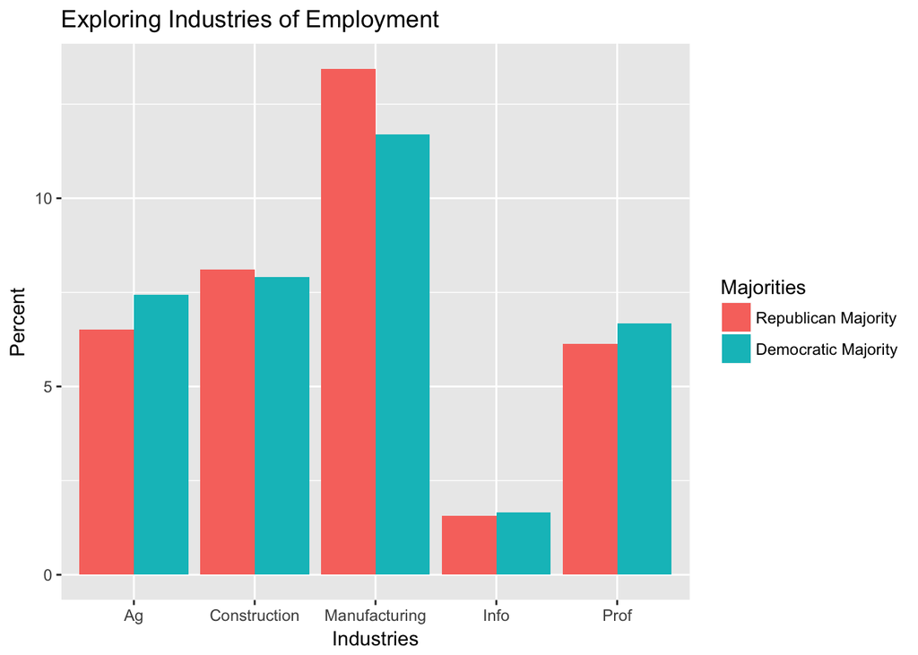

```r
#- HC03_VC50,"Percent; INDUSTRY - Agriculture, forestry, fishing and hunting, and mining"
#- HC03_VC51,Percent; INDUSTRY - Construction
#- HC03_VC52,Percent; INDUSTRY - Manufacturing
#- HC03_VC56,Percent; INDUSTRY - Information
#- HC03_VC58,"Percent; INDUSTRY - Professional, scientific, and management, and administrative and waste management services"
industryDataFrame <- data.frame("Ag" = masterFrame$dp03_HC03_VC50, "Construction" = masterFrame$dp03_HC03_VC51, "Manufacturing" = masterFrame$dp03_HC03_VC52,  "Info" = masterFrame$dp03_HC03_VC56, "Prof" = masterFrame$dp03_HC03_VC58)
industryDataFrame['cond'] <- cond
industryDataFrame = melt(industryDataFrame, id.vars = "cond")

ggplot(industryDataFrame, aes(x = variable, y = value, fill = as.factor(cond))) +
       geom_bar(stat="summary",position="dodge", fun.y = "mean") +
      labs(title = "Exploring Industries of Employment") +
      scale_x_discrete("Industries") +
      scale_y_continuous("Percent") +
     scale_fill_discrete("Majorities",
                      labels=c("Republican Majority", "Democratic Majority"))
```

*Description* - This plot is an initial exploration of the different job industries of the two parties. It seems like many more Republican counties have Manufacturing jobs, while Professional and Agriculture lean Democrat. Less notable differences include Information, which shows more Democratic counties, and Construction which is more Republican.

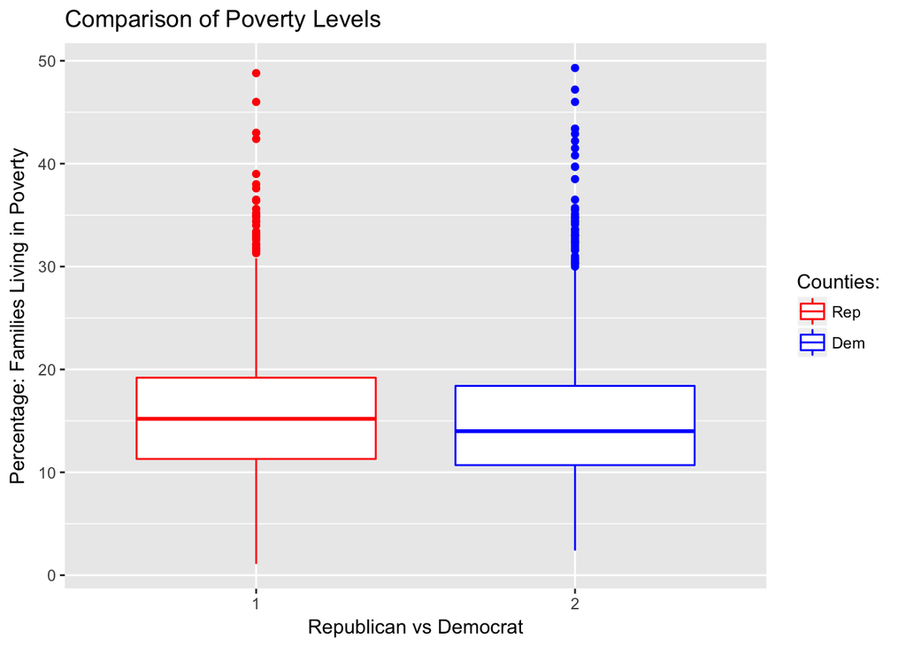

```r
#Superposed density plot to show differences in poverty levels
povertyDF <- masterFrame[, c("demVoteCount2012", "repVoteCount2012", 'dp03_HC03_VC166')]
povertyDF['cond'] <- cond

ggplot(data = povertyDF, aes(x = as.factor(cond), y = dp03_HC03_VC166, color = as.factor(cond))) + geom_boxplot() +
      labs(title = "Comparison of Poverty Levels ") +
      scale_x_discrete("Republican vs Democrat") +
      scale_y_continuous("Percentage: Families Living in Poverty") +
  scale_color_manual(name = "Counties: ", values = c("red", "blue"), labels = c("Rep", "Dem"))
```

# Map

### Polarity of maps based on slant from 2012 to 2016 for each county

** Done by Vinitra **

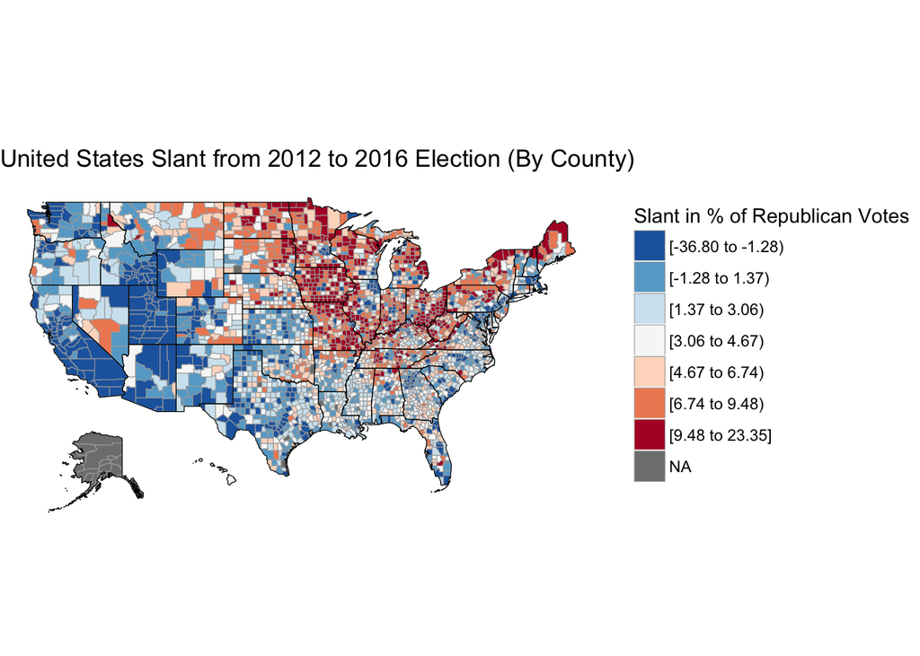

```r
red2016 <- round(masterFrame$perRepVotes2016 * 100, 2)
blue2016 <- round(masterFrame$perDemVotes2016 * 100, 2)
red2012 <- as.numeric(gsub("%", "", masterFrame$perRepVotes2012))
blue2012 <- as.numeric(gsub("%", "", masterFrame$perDemVotes2012))

redSlant <- red2016 - red2012
blueSlant <- blue2016 - blue2012

df_pop_county = data.frame(masterFrame$geoIDs, redSlant)
df_pop_county <- setNames(df_pop_county, c("region", "value"))

choro = CountyChoropleth$new(df_pop_county)
choro$title = "United States Slant from 2012 to 2016 Election (By County)"
choro$ggplot_scale = scale_fill_brewer(name = "Slant in % of Republican Votes", direction=-1, palette="RdBu", drop=FALSE, na.value="grey50")
choro$render()
```

For our national map, we wanted describe the 2016 results in the context of the 2012 election on a county-by-county basis. Originally, we decided to create a scatter plot with colors reflecting degree of slant in the republican or democratic decision and size representing the population of people. However, we found this initial plot hard to understand and not as effective in conveying the information that we wanted to get across. We then discovered the choroplethr package and reflected our data in terms of percentage shifts for county, which was effective in showing the general trends on the scale of the entire nation. We were able to notice a clear shift towards the republican candidate, Trump, in the midwest and a more general shift towards the democratic vote in the pacific northwest. We also noticed a clear general trend towards the red vote nationwide – the national average shifted ~3% towards Republican, as reflected in the scale.

# Predicting the 2016 Results

# Predicting the Change From 2012 to 2016

To predict the change from 2012 to 2016 we tried to identity variables that correspond with a Republican lean. We picked our parameter variables after our initial data exploration and examining the map. There are also a lot of articles about The Rust Belt and the change in the Midwest. We tried to capture the characteristics of this region in our parameters - namely education and jobs such as manufacturing.

### Plots exploring the factors

```r
summary(masterFrame$dp03_HC03_VC52)
```

```
##    Min. 1st Qu.  Median    Mean 3rd Qu.    Max.
##    0.00    7.00   11.90   12.71   17.30   43.70
```

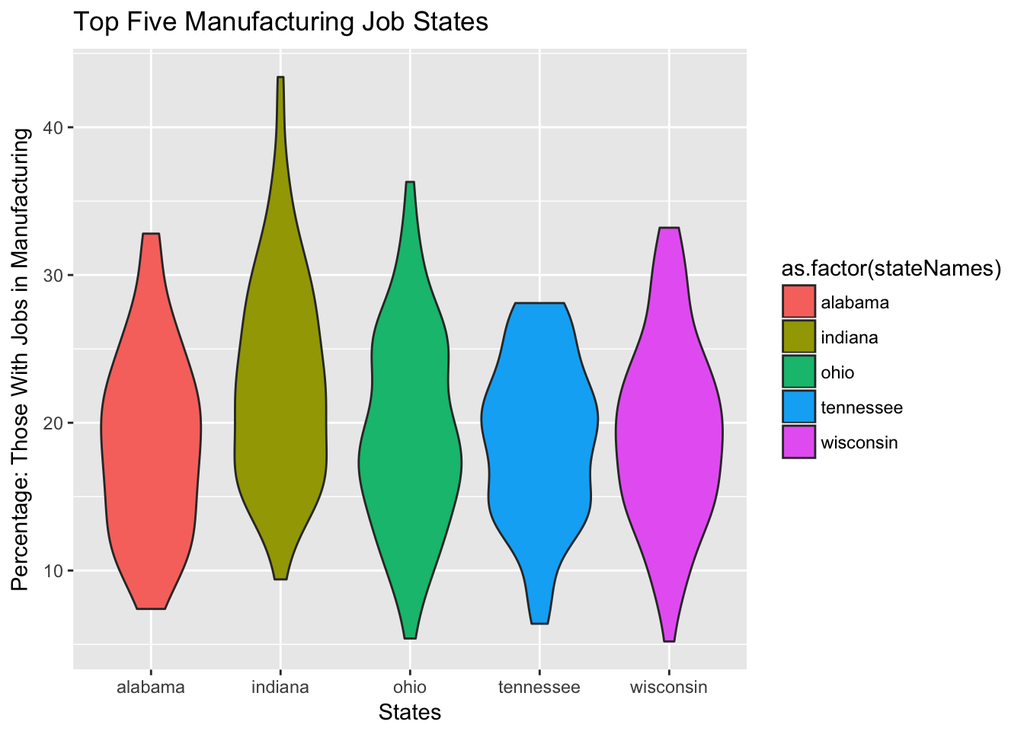

```r
manufStatesDist <- masterFrame[, c("demVoteCount2012", "repVoteCount2012", 'dp03_HC03_VC52')]
manufStatesDist['cond'] <- cond

manufStates <- masterFrame[, c("stateNames", "dp03_HC03_VC52")]
topStates <- aggregate(dp03_HC03_VC52 ~ stateNames, data = manufStates, mean)
topStates <- unique(arrange(topStates, -dp03_HC03_VC52))[1:5, "stateNames"]
manufStates <- manufStates[which(manufStates$stateNames %in% topStates),]

ggplot(manufStates, aes(x = stateNames, y = dp03_HC03_VC52, fill = as.factor(stateNames))) + geom_violin() +
      labs(title = "Top Five Manufacturing Job States") +
      scale_x_discrete("States") +
      scale_y_continuous("Percentage: Those With Jobs in Manufacturing") +
  scale_color_manual(name = "Counties: ", values = c("red", "blue"), labels = c("Rep", "Dem"))
```

*Description* - Manufacturing stood out to us, and we decided to take a closer look at it. We created a new data frame that finds the states with the highest percentage of manufacturing jobs across its counties. We looked at this and compared it with the map to see if there was overlap with key areas such as the Midwest. We plotted the top five states using a violin plot to examine their distributions. The top five States all leaned Republican and Wisconsin is considered an important Swing State. Indiana has a tail and is positively skewed.

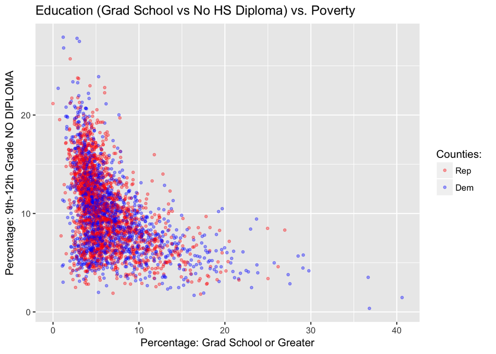

```r
#HC03_VC91 = grad school or greater
#HC03_VC86 = 12th grade no hs diploma (drop out)

educLowHigh <- masterFrame[, c('dp02_HC03_VC91', 'dp02_HC03_VC86', 'dp03_HC03_VC166')]
educLowHigh['cond'] <- cond
ggplot(data = educLowHigh) +
      geom_point(mapping = aes(x = dp02_HC03_VC91, y = dp02_HC03_VC86, color = factor(cond)), size = 1, position = "jitter", alpha = 0.35) +
      labs(title = "Education (Grad School vs No HS Diploma) vs. Poverty") +
      scale_x_continuous("Percentage: Grad School or Greater") +
      scale_y_continuous("Percentage: 9th-12th Grade NO DIPLOMA") +
      scale_color_manual(name = "Counties: ", values = c("red", "blue"), labels = c("Rep", "Dem"))
```

*Description* - We decided to take a closer look at the educational factors at the ends of the spectrum - those with no High School diploma and those with a graduate degree or higher. As expected there is a negative correlation, meaning counties with a highly educated population have less percentage of people with no High School diploma and vice versa. There’s some extreme Democrat leaning outliers for Graduate School or higher. The counties with more people with Graduate degrees are higher seem to favor Democrats.

## Step 5.1a, Obtaining electoral votes per state for the classifier

Taken from https://rpubs.com/bhaskarvk/electoral-Map-2016. Creates a simple data frame of state to electoral votes

```r
library(leaflet)
```

```r
library(magrittr)

# The URL for election forecast
url <- 'http://projects.fivethirtyeight.com/2016-election-forecast/?ex_cid=2016-senate-forecast'

g <- xml2::read_html(url)

# These divs hold our data
state.winprobs <- g %>% rvest::html_nodes('.cards')
state.winprobs <- state.winprobs[2:52] # Select only state data

# How many electoral votes per state
electoral.votes <- purrr::map_chr(state.winprobs,
                                  function(winprob) {
                                    winprob %>%
                                      rvest::html_node('p.top-powerbar') %>%
                                      rvest::html_text()
                                  }) %>%
  stringr::str_extract('[0-9]+') %>% as.numeric()

# 2 letter abbreviations for the states
states <- purrr::map_chr(state.winprobs,
                         function(winprob) {
                           winprob %>%
                             rvest::html_node('div.card-winprob') %>%
                             rvest::html_attr('data-card-id')
                         }) %>%
  stringr::str_extract('^..')
states <- tolower(states)

electoralVotesDF = data.frame(states, electoral.votes)
```

## Step 5.1b, Naive Bayes Classification

Creates a naive bayes classifier for the result of a county (i.e. republican or democrat). After that, we use the distribution likelihood rather than the label to do weighted number of votes per county. For instance, since the classifer gives us the P(county votes democratic | census data), we calculate the expected number of democratic votes with county population * P(county votes democratic | census data). We them sum up the county votes in a state and which ever party has a simple majority, we allocate that number of electoral votes to it.

Cool features of e1071– Continuous variables use a normal distribution to calculate the probability. This means we don’t have to discretize time at all.

**Done by Allen**

```r
# For debugging purposes
library(e1071)
load("ElectionsDataFrame.rda")

# Data must be numeric. ADD THIS FIX BEFORE TURNING IN DATA FRAME.
masterFrame$repVoteCount2012 = as.numeric(masterFrame$repVoteCount2012)
masterFrame$demVoteCount2012 = as.numeric(masterFrame$demVoteCount2012)
masterFrame$demVoteCount2004 = as.numeric(masterFrame$demVoteCount2004)
masterFrame$repVoteCount2004 = as.numeric(masterFrame$repVoteCount2004)

masterFrame$dp03_HC01_VC112 = as.numeric(masterFrame$dp03_HC01_VC112)
masterFrame$dp03_HC01_VC122 = as.numeric(masterFrame$dp03_HC01_VC122)
masterFrame$dp03_HC01_VC123 = as.numeric(masterFrame$dp03_HC01_VC123)
masterFrame$dp02_HC03_VC140 = as.numeric(masterFrame$dp02_HC03_VC140)

# Label based on 2012 winner
masterFrame$countyWinner2012 = masterFrame$demVoteCount2012 > masterFrame$repVoteCount2012
masterFrame$countyWinner2012 = factor(masterFrame$countyWinner2012, levels=c(FALSE,TRUE) ,labels=c("Rep", "Dem"))

# Getting rid of percentages, state names, counties, etc. Rationale is that count should be sufficient
columnsToRemove = c(seq(1, 8),10,12,14,16) * -1
testingData = split(masterFrame, masterFrame$stateAbbr)
stateAbbr = unique(masterFrame$stateAbbr)
countyPopulation = lapply(testingData, function(x) x[,"totalPopulation"]) # Indexed by state. Each element is a list of population per county
testingData = lapply(testingData, function(x) x[,columnsToRemove]) # We want this data to be refed to calculate the 2016 results.

trainingData = masterFrame[,columnsToRemove] # We want to calculate the posterior distribution with this data

model <- naiveBayes(countyWinner2012 ~ ., data = trainingData) # Generate the posterior distribution with Naive Bayes

# Calculates the probability distribution of voting Republican and Democrat. Predict is vectorized, so I can pass in an entire state
predictCountyDistribution = function(state) {
  predict(model, state, type="raw")
}

votingLikelihood = lapply(testingData, predictCountyDistribution) #Indexed by state

# Calculating the expected votes for Republican and Democrat per state
expectedWinnerPerState = function(i) {
  distributionVector = as.vector(t(votingLikelihood[[i]]))
  countyPopulationVector = rep(countyPopulation[[i]], rep(2, length(countyPopulation[[i]])))
  expectedVotesByCounty = matrix(distributionVector * countyPopulationVector, ncol = 2, byrow = TRUE) # Left is Republican
  expectedPartyVotes = colSums(expectedVotesByCounty)
  if (expectedPartyVotes[1] > expectedPartyVotes[2]) {
    return("Republican Vote")
  } else {
    return("Democrat Vote")
  }
}
resultsColumn = factor(sapply(1:length(stateAbbr) , expectedWinnerPerState))
resultsDF = data.frame(stateAbbr, resultsColumn)

stateVotesResultDF = merge(resultsDF, electoralVotesDF, by.x="stateAbbr", by.y="states")
recast(stateVotesResultDF, resultsColumn ~ ., fun.aggregate=sum)
```

```
##     resultsColumn   .
## 1   Democrat Vote 336
## 2 Republican Vote 191
```

```r
# Calculating Error Rate of Counties

predictCountyResults = function(state) {
  predict(model, state)
}

masterFrame$countyWinner2016 = masterFrame$demVoteCount2016 > masterFrame$repVoteCount2016
masterFrame$countyWinner2016 = factor(masterFrame$countyWinner2016, levels=c(FALSE,TRUE) ,labels=c("Rep", "Dem"))
masterFrame$predictedWinner2016 = predictCountyResults(masterFrame)
errorRate = sum(masterFrame$countyWinner2016 != masterFrame$predictedWinner2016) / length(masterFrame$countyWinner2016)
```

## Classification Tree

### Creating testing and training data

*Done by Kimberly and Derrick*

```r
set.seed(24687531)
states <- unique(masterFrame$stateNames)

stateDFs <- split(masterFrame, masterFrame$stateNames)

stateDFCalc <- function(stateDF){
  totalStateCounties <- force(nrow(stateDF))
  sampleSize <- totalStateCounties * 0.20
  sample(totalStateCounties, size = sampleSize, replace = FALSE)
  }

sampleNumList <- lapply(stateDFs, stateDFCalc)

indices <- 1:length(stateDFs)


stateTest <- lapply(indices, function(i)stateDFs[[i]][sampleNumList[[i]],])
stateTest <- do.call(rbind.data.frame, stateTest)

set.seed(24687567)
sampleNumList <- lapply(stateDFs, stateDFCalc)

stateTrain <-lapply(indices, function(i)stateDFs[[i]][sampleNumList[[i]],])
stateTrain <- do.call(rbind.data.frame, stateTrain)

#Idk if we need it by states
# A function that creates a factor to determine what counties changed votes
stateTrain$change = factor(c("dd", "rr", "dr", "rd"))
# Apply known voting changes to our training data
stateTrain[which(stateTrain$countyWinner2012 == "Rep" & stateTrain$countyWinner2016 == "Rep"), "change"] <- "rr"

stateTrain[which(stateTrain$countyWinner2012 == "Dem" & stateTrain$countyWinner2016 == "Dem"), "change"] <- "dd"

stateTrain[which(stateTrain$countyWinner2012 == "Dem" & stateTrain$countyWinner2016 == "Rep"), "change"] <- "dr"

stateTrain[which(stateTrain$countyWinner2012 == "Rep" & stateTrain$countyWinner2016 == "Dem"), "change"] <- "rd"
```

Creating a classfier tree on 2012 data to predict 2016 election

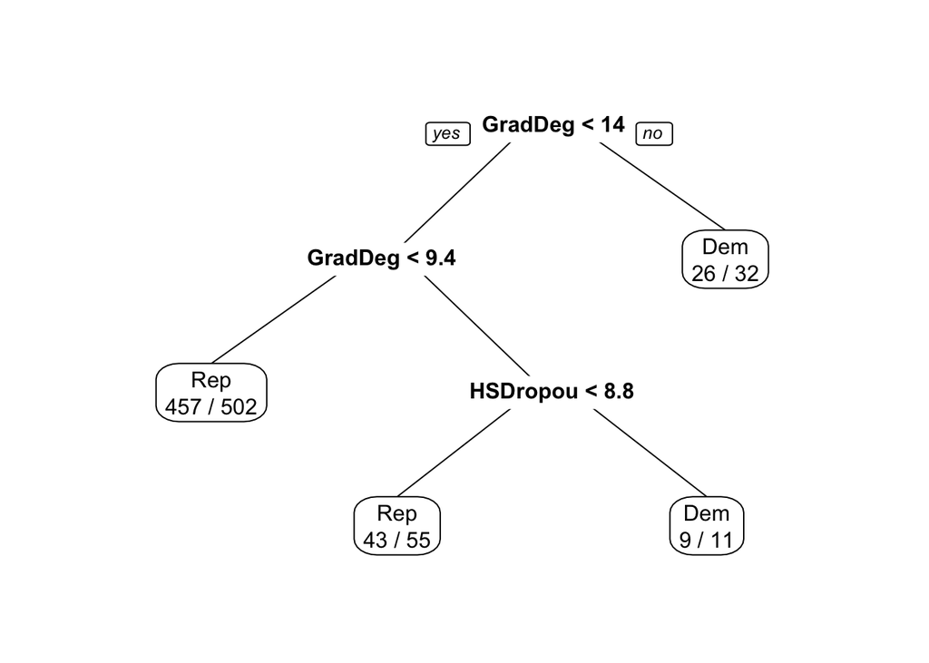

```r
# Subsetting factors that mater to our predictor
keeps <- c("dp02_HC03_VC91", "dp02_HC03_VC86", "dp03_HC03_VC56", "countyWinner2016")
temp <- stateTrain[, keeps]
colnames(temp) <- c("GradDeg", "HSDropout", "Manufacturing", "countyWinner2016")

votingChangeTree <- rpart(temp$countyWinner2016 ~ .,
                  data = temp, method = "class",
                  control = rpart.control(cp = 0.026))

prp(votingChangeTree, extra = 2)
```

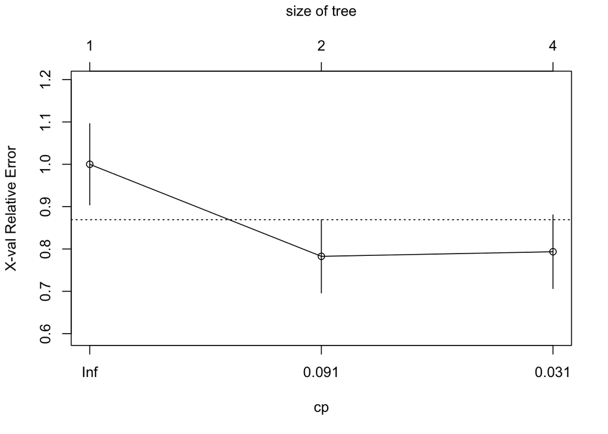

```r
plotcp(votingChangeTree)
```

Confusion matrix to assess our classifier results

```r
pred <- predict(votingChangeTree, type="class")
table(pred)
```

```
## pred
## Rep Dem
## 557  43
```

```r
table(stateTrain$countyWinner2016, pred)
```

```
##      pred
##       Rep Dem
##   Rep 500   8
##   Dem  57  35
```

# Discussion

### Naive Bayes Classifier - Allen & Shanaaz

We created a naive bayes classifier for the result of a county (i.e. Republican or Democrat). After that, we use the distribution likelihood rather than the label to do weighted number of votes per county. For instance, since the classifier gives us the P(county votes democratic | census data), we calculate the expected number of democratic votes with county population * P(county votes democratic | census data). We them sum up the county votes in a state and whichever party has a simple majority, we allocate that number of electoral votes to it. The error rate is 0.1101066.

# References

Presidential Polls: http://projects.fivethirtyeight.com/2016-election-forecast/

2016 Presidential Election Data = http://www.stat.berkeley.edu/users/nolan/data/voteProject/2016_US_County_Level_Presidential_Results.csv

2012 Presidential Election Results = http://www.politico.com/2012-election/map/#/President/2012/

2008 Presidential Election Results = https://www.theguardian.com/news/datablog/2009/mar/02/us-elections-2008

2004 Presidential Election Results= http://www.stat.berkeley.edu/users/nolan/data/voteProject/countyVotes2004.txt

2010 Census Data = http://factfinder2.census.gov/faces/nav/jsf/pages/searchresults.xhtml?refresh=t

GML Data for latitude and longitude of each county = http://www.stat.berkeley.edu/users/nolan/data/voteProject/counties.gml

RPart Documentation = http://cran.r-project.org/web/packages/rpart/rpart.pdf

Chosing our parameters = https://www.washingtonpost.com/posteverything/wp/2016/11/09/the-rust-belt-was-turning-red-already-donald-trump-just-pushed-it-along/?utm_term=.887835ccde47